# Análise sobre avaliações de séries de TV pelo IMDb

## Introdução

Neste relatório, serão analisados as avaliações dos episódios e das temporadas de três séries de TV: Friends, Desperate Housewives e House. As perguntas as serem respondidas incluem qual das séries é mais bem avaliada, qual possui episódios de qualidade mais irregular, qual das séries ou temporadas tem episódios mais sem graça e o que tende a ser melhor: inícios ou finais de séries/temporadas.

#### Importando os dados

O primeiro passo desta análise é importar os dados a serem utilizados e filtrar as séries de interesse.

```r
episodes = read_csv(here("data/series_from_imdb.csv"),
                    progress = FALSE,
                    col_types = cols(.default = col_double(),
                                     series_name = col_character(),
                                     episode = col_character(),
                                     url = col_character(),
                                     season = col_character())) %>%
    filter(series_name %in% c("Friends", "Desperate Housewives", "House"))
```

[output not shown]

## Perguntas

### Qual das séries é mais bem avaliada no IMDB? A diferença é grande? Pequena? Muda de acordo com as temporadas da série?

O critério para escolha da série mais bem avaliada foi escolhido de acordo com a média do valor da proporção de usuários que votaram nota máxima em cada episódio.

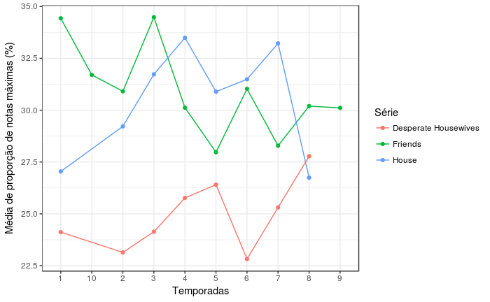

No gráfico é possível visualizar a relação entre as temporadas das séries e a média do valor da proporção de usuários que votaram nota máxima em cada episódio no decorrer das temporadas. A série mais bem votada é **Friends**, possuindo mais notas máximas dentre as demais avaliações por episódio. Este seriado liderou as demais principalmente durante as temporadas 1 e 3, possuindo quase 35% das notas com valor máximo. Nota-se que, a partir da 3ª temporada, essa proporção diminuiu drasticamente, chegando a seu mínimo na 5ª temporada, com valor igual a 28%. Uma possível razão para essa queda seria o término do casal Rachel e Ross e o novo namoro de Ross com Emily. **House** ocupou a segunda posição do ranking, com avaliação crescete ao longo das temporadas e dominando as melhores avaliações durante 4 temporadas: 4ª, 5ª, 6ª a 7ª. Acredito que a queda na 8ª temporada se deva pelas **alerta de spoiler** mortes de personagens importantes da série. **Desperate Housewives** ficou em último lugar, possuindo avaliação crescente com exceção principalmente da 6ª temporada, que teve o valor mínimo entre todas as temporadas de todas as séries. Acredito que esta queda ocorreu devido ao mistério envolvendo o estrangulador de Fairview, além da catástrofe envolvendo a queda de um avião dentro do condomínio onde as principais personagens residem.

### Qual das séries tem episódios de qualidade mais irregular segundo o IMDB? A diferença é grande? Pequena?

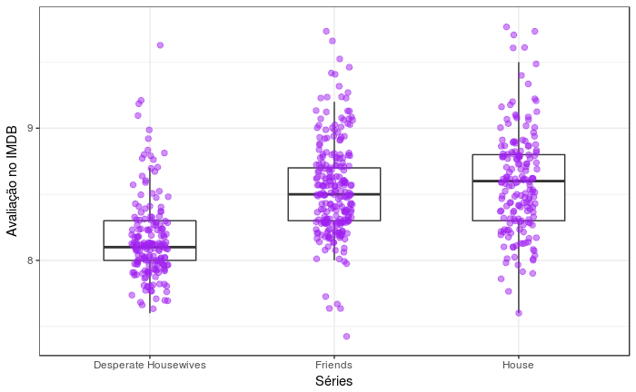

### Qual das séries ou temporadas tem episódios mais sem graça? (Um episódio é sem graça se ninguém nem ama nem odeia ele)

Os episódios foram considerados sem graça de acordo com a proporção de votos iguais a 5 (considerados neutros) em relação ao número total de votos.

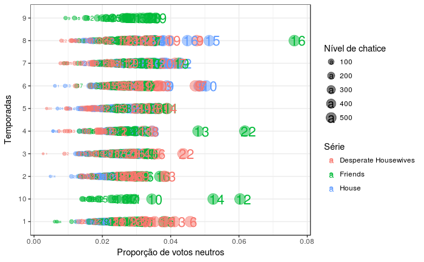

```r
episodes =  episodes %>%
    mutate(
        rank_odiados = row_number(r1), # maior = mais odiado
        rank_amados = row_number(r10), # maior = mais amado
        rank_sem_graca = row_number(r5), # maior = mais sem graca,
        amado_odiado = rank_amados * rank_odiados) # maior = mais amado E odiado
episodes %>% group_by(series_name) %>%
    ggplot(aes(
        x = r5,
        y = season,
        color = series_name,
        label = season_ep,
        size = rank_sem_graca
    )) +
    geom_point(alpha = .5) +
    geom_text(nudge_x = .001, nudge_y = -.01) +
  labs(y = "Temporadas", x = "Proporção de votos neutros") +
  guides(color=guide_legend("Série"), size = guide_legend("Nível de chatice"))
```

**Friends** é a série que possui mais episódios sem graça, seguido por House e Desperate Housewives. Dentre as temporadas da série, as que possuem episódios mais sem graça são as temporadas 4 e 10. O episódio mais chato de todos os tempos de acordo com os votos dos usuários é **S8E16 - The One Where Joey Tells Rachel**, onde Joey conta para Rachel que está apaixonado por ela, provavelmente uma parcela das pessoas torciam pelo casal, enquanto a outra torcia por Rachel e Ross. O segundo episódio mais chato da série é **S4E22 - The One with the Worst Best Man Ever**, onde os três personagens masculinos discutem sobre quem será o padrinho de casamento dos outros e Joey acaba perdendo o anel de casamento. Esse episódio ser considerado o segundo mais chato me surpreendeu pois nele também ocorre o chá de bebê da Phoebe (que considero a personagem mais engraçada do seriado) e tem cenas bem engraçadas. O terceiro episódio mais chato é também da série Friends, o **S10E12 - The One With Phoebe’s Wedding**, onde Phoebe se casa, apesar de tudo dar errado o episódio quase todo, motivo que pode ter causado essa posição de chatice do episódio.

### Episódios no início/fim da temporada são mais bem avaliados que os no meio? O que tende a ser melhor? Inícios ou finais de séries/temporadas?

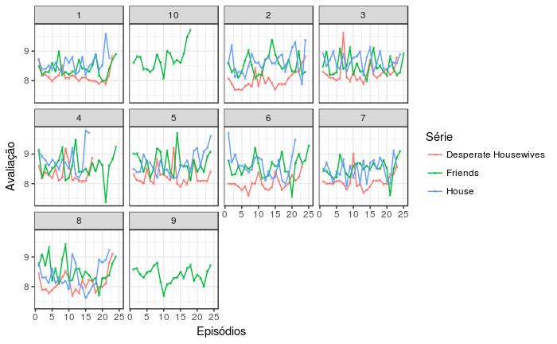

```r
episodes %>% group_by(series_name) %>%
  ggplot(aes(x = season_ep, y = user_rating, color = series_name)) +
  geom_jitter(width = .1, size = .5, alpha = .5) +
  geom_line() +
  labs(x = "Episódios", y = "Avaliação") +
  facet_wrap(~ season) +
  guides(color=guide_legend("Série"))
```

### Qual o episódio mais detestado?

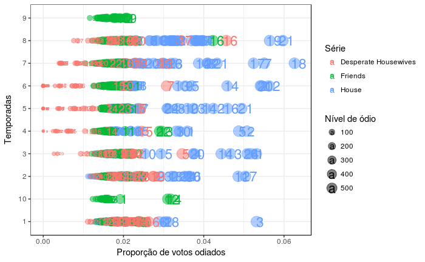

House lidera de longe os episódios mais odiados pelo IMDb. O episódio mais odiado é o **S7E18 - The Dig** e a razão só saberei quando terminar a série. (Estou na quinta temporada e postarei a minha opinião sobre o episódio assim que assisti-lo!). O episódio mais odiado de Friends também é o **S8E16 - The One Where Joey Tells Rachel**, o que Joey conta para Rachel que está apaixonado por ela. Coincidentemente, o episódio mais odiado de Desperate Housewives também possui a mesma numeração do episódio de Friends: **S8E16 - You Take for Granted**, onde Mike Delfino, um dos personagens principais e mais queridos (na minha opinião) morre, por um motivo banal e na calçada de casa. Este com certeza mereceu o título de mais odiado da série inteira.

### E amado?

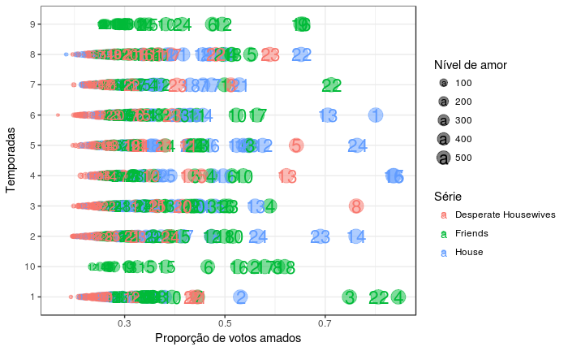

```r
episodes %>% group_by(series_name) %>%
    ggplot(aes(
        x = r10,
        y = season,
        color = series_name,
        label = season_ep,
        size = rank_amados)) +
    geom_point(alpha = .5) +
    geom_text(nudge_x = .001, nudge_y = -.01) +
  labs(y = "Temporadas", x = "Proporção de votos amados") +
  guides(color=guide_legend("Série"), size = guide_legend("Nível de amor"))
```

Friends possui os episódios mais amados dentre as demais série, destacando-se três episódios da primeira temporada: **S1E3 - The One With the Thumb**, onde Phoebe vai ganhando mais dinheiro conforme vai fazendo boas ações, **S1E4 - The One with George Stephanopoulos**, em que os meninos levam Ross para sair e esquecer o aniversário de casamento com a ex esposa e **S1E22 - The One with the Ick Factor**, onde tem o namorado novo da Monica e Chandler descobrindo que ninguém do trabalho gosta dele.